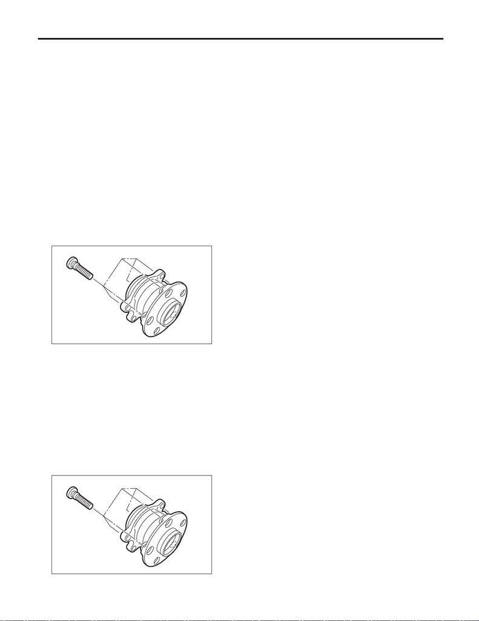

Wheel Bearing

PERIODIC MAINTENANCE SERVICES

22.Wheel Bearing

A: INSPECTION

1. FRONT WHEEL BEARING

NOTE:

Inspect the condition of front wheel bearing grease.

1) Jack-up the front side of vehicle.

2) While holding the front wheel by hand, swing it in and out to check bearing free play.

3) Loosen the wheel nuts, and remove the front wheel.

axial direction.

Service limit:

Straight-ahead position within 0.05 mm (0.0020 in)

5) Remove the bolts and self-locking nuts, and extract the front arm from front crossmember.

Axle.>

for noise or binding.

If the hub is noisy or binds, replace the front axle.

2. REAR WHEEL BEARING

1) Jack-up the rear side of vehicle.

2) While holding the rear wheel by hand, swing it in and out to check bearing free play.

3) Loosen the wheel nuts, and remove the rear wheel.

axial direction.

Service limit:

Straight-ahead position within 0.05 mm (0.0020 in)

5) Remove the DOJ of rear drive shaft from rear differential. <Ref. to DS-64, Rear Drive Shaft.>

noise or binding.

If the hub is noisy or binds, replace the rear axle.